# Normalization performance report

- study: Illumina methylation data
- author: Analyst
- date: 14 April, 2021

## Parameters used to test normalization

```
## $variables
## [1] "Slide"        "Array"        "Sample_Plate" "Sex"
##
## $control.pcs
## [1] 1 2 3 4 5
##
## $batch.pcs
## [1] 1 2 3 4 5
##
## $batch.threshold
## [1] 1e-30
##
## $colours
## NULL
```

## Control probe scree plots

The variance captured by each principal component.

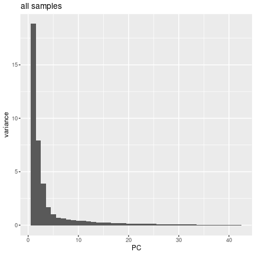

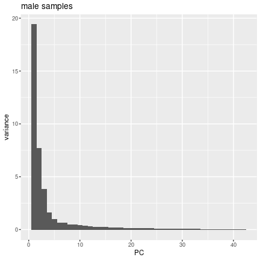

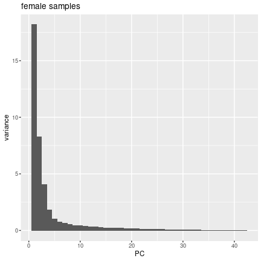

## Principal components of the control probes

The following plots show the first 3 principal components of the control matrix colored by batch variables. Batch variables with more than 10 levels are omitted.

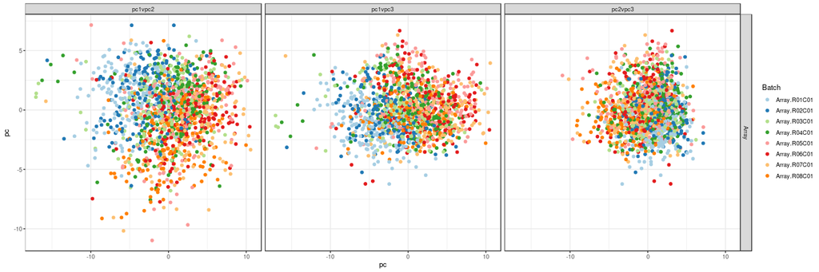

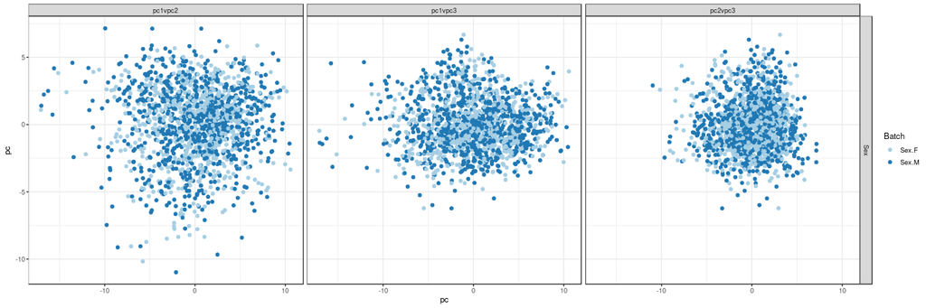

## Control probe associations with measured batch variables

Principal components of the control probes were regressed against batch variables. Shown are the \(-log_{10}\) p-values for these regressions. The horizontal dotted line denotes \(p = 0.05\) in log-scale.

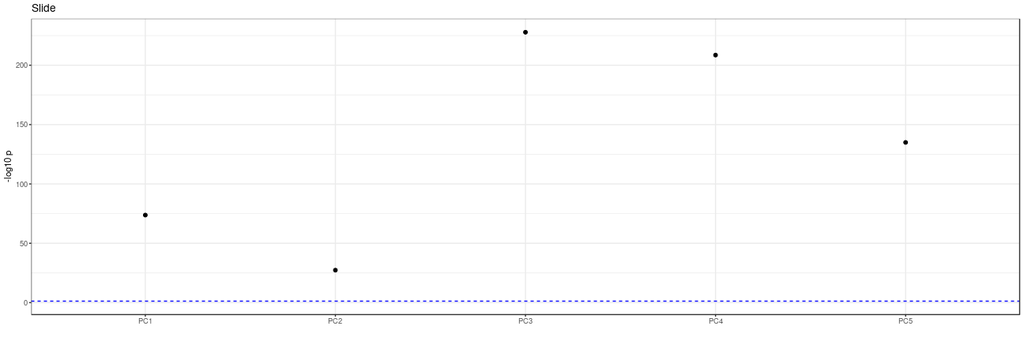

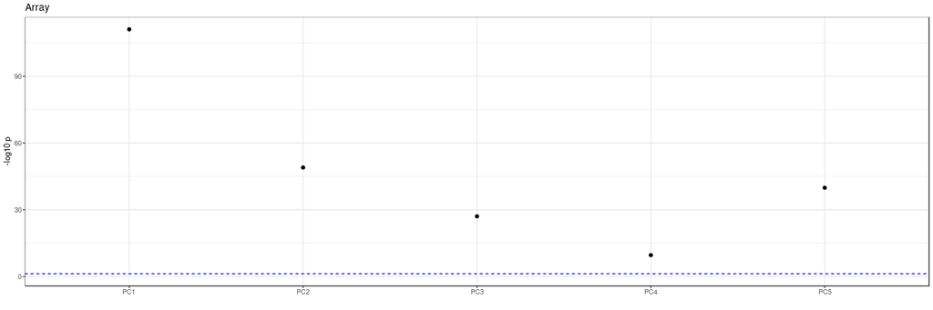

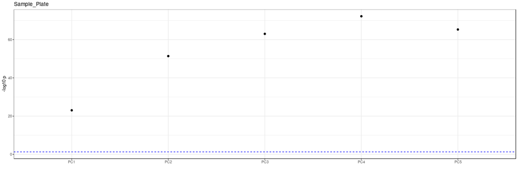

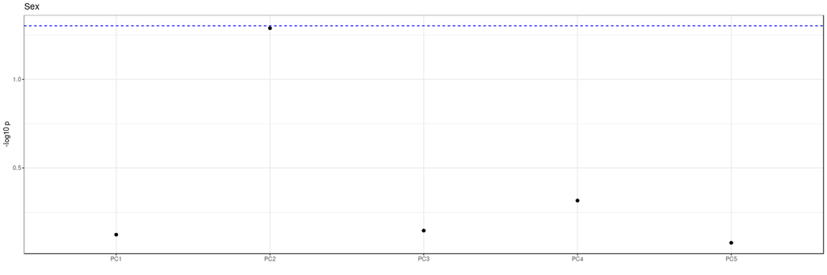

The following plots show regression coefficients when each principal component is regressed against each batch variable level along with 95% confidence intervals. Cases significantly different from zero are coloured red (p < 10<sup>-30</sup>, t-test).

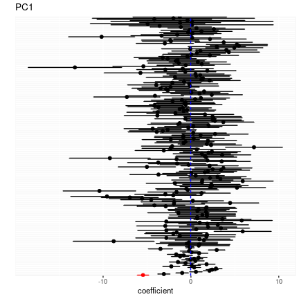

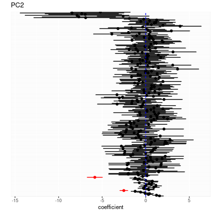

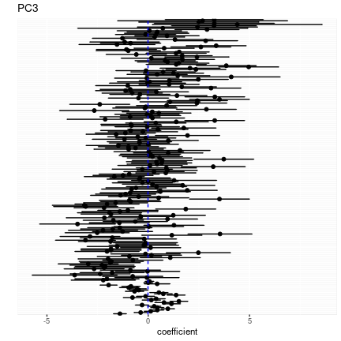

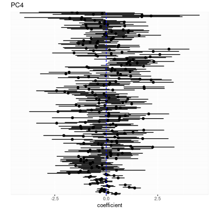

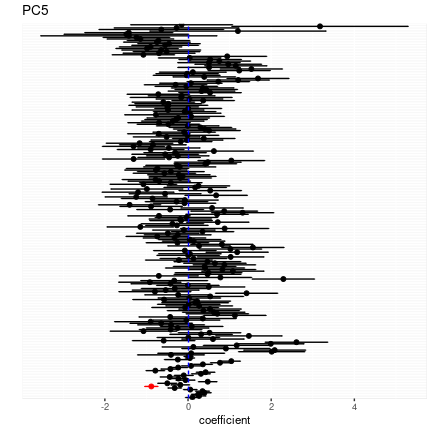

| batch.variable | batch.value | principal.component | test | p.value | estimate | lower | upper |
| --- | --- | --- | --- | --- | --- | --- | --- |
| Slide |  | PC1 | F-test | 1.75e-74 | 5.019 |  |  |
| Array |  | PC1 | F-test | 7.78e-112 | 91.981 |  |  |
| Array | R01C01 | PC1 | t-test | 1.14e-69 | -5.455 | -6.11 | -4.801 |
| Array |  | PC2 | F-test | 9.63e-50 | 38.341 |  |  |
| Array | R08C01 | PC2 | t-test | 2.22e-33 | -2.514 | -2.97 | -2.060 |
| Sample_Plate |  | PC2 | F-test | 4.15e-52 | 19.840 |  |  |
| Sample_Plate | B0017 | PC2 | t-test | 3.92e-47 | -5.843 | -6.72 | -4.968 |
| Slide |  | PC3 | F-test | 1.58e-228 | 14.562 |  |  |
| Sample_Plate |  | PC3 | F-test | 9.69e-64 | 24.141 |  |  |
| Slide |  | PC4 | F-test | 2.71e-209 | 13.099 |  |  |
| Sample_Plate |  | PC4 | F-test | 6.08e-73 | 27.638 |  |  |
| Slide |  | PC5 | F-test | 1.05e-135 | 8.284 |  |  |
| Array |  | PC5 | F-test | 1.21e-40 | 31.247 |  |  |
| Array | R08C01 | PC5 | t-test | 1.01e-33 | -0.883 | -1.04 | -0.724 |
| Sample_Plate |  | PC5 | F-test | 5.15e-66 | 24.998 |  |  |

## Principal components of the normalized betas

The following plots show the first 3 principal components of the most variable probes colored by batch variables. Batch variables with more than 10 levels are omitted.

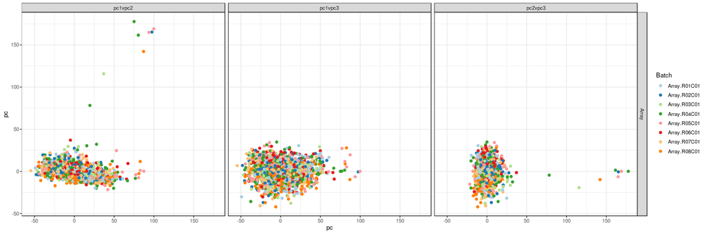

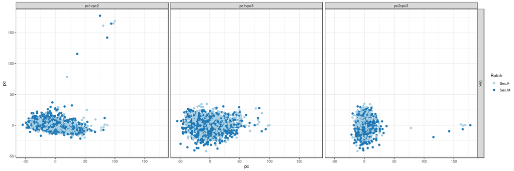

## Normalized probe associations with measured batch variables

The most variable normalized probes were extracted, decomposed into principal components and each component regressed against each batch variable. If the normalization has performed well then there will be no associations between normalized probe PCs and batch variables. Horizontal dotted line denotes \(p = 0.05\) in log-scale.

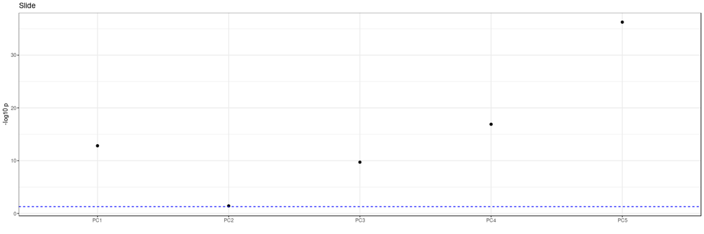

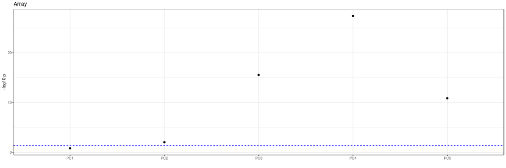

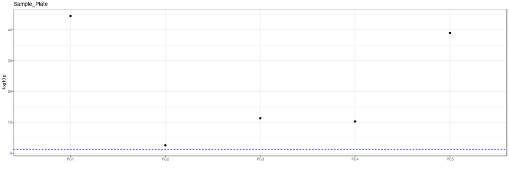

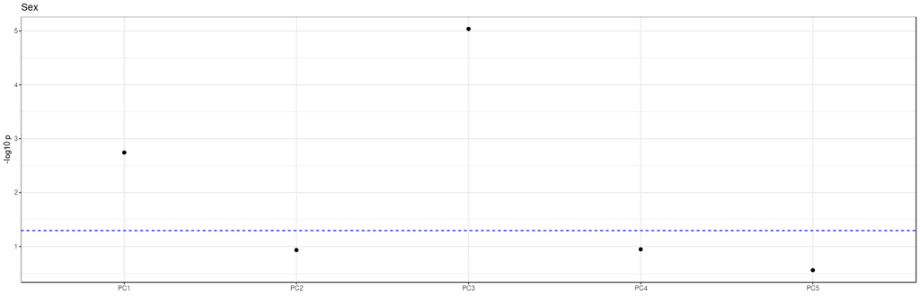

The following plots show regression coefficients when each principal component is regressed against each batch variable level along with 95% confidence intervals. Cases significantly different from zero are coloured red (p < 10<sup>-30</sup>, t-test).

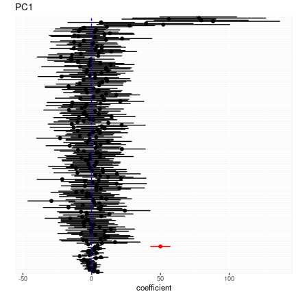

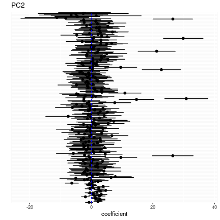

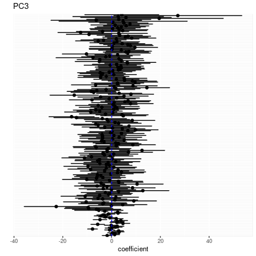

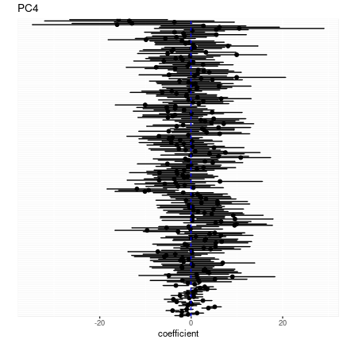

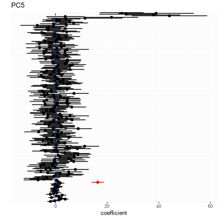

| batch.variable | batch.value | principal.component | test | p.value | estimate | lower | upper |
| --- | --- | --- | --- | --- | --- | --- | --- |
| Sample_Plate |  | PC1 | F-test | 3.30e-45 | 17.34 |  |  |
| Sample_Plate | B0017 | PC1 | t-test | 2.67e-52 | 49.93 | 42.9 | 57.0 |
| Slide |  | PC5 | F-test | 5.63e-37 | 3.21 |  |  |
| Sample_Plate |  | PC5 | F-test | 1.03e-39 | 15.38 |  |  |
| Sample_Plate | B0017 | PC5 | t-test | 4.49e-51 | 16.34 | 14.0 | 18.7 |